# CUIP Fully Data Analysis

JD Long

8/22/2019

## Fetch Data

Download the full dataset from utccuip.com:

Block turned off as it only needs to run once

```r
url <-"http://cscdc-2019.utccuip.com/CSCDC+Dataset.zip"
dest_file <- "01_data/CSCDC+Dataset.zip"

download.file(url, dest_file)
unzip(zipfile = dest_file, exdir = "01_data/CSCDC+Dataset/")
```

Load up a few libraries

## Air Quality Data

Grab the air quality data then give it a quick `skim` (from the `skimr` package):

### Air Quality Skim

```r
air_quality <- read_csv("01_data/CSCDC+Dataset/air_quality_csv/all.csv")

## have to force the formatting on the timestamp.
air_quality %>%
  mutate( `timestamp-iso` = mdy_hm(`timestamp-iso`)) ->
  air_quality

skim(air_quality)  %>% kable()
```

Skim summary statistics  
n obs: 105726  
n variables: 34

Variable type: character

| variable | missing | complete | n | min | max | empty | n_unique |
| --- | --- | --- | --- | --- | --- | --- | --- |
| nicename | 0 | 105726 | 105726 | 11 | 12 | 0 | 7 |

Variable type: numeric

| variable | missing | complete | n | mean | sd | p0 | p25 | p50 | p75 | p100 | hist |
| --- | --- | --- | --- | --- | --- | --- | --- | --- | --- | --- | --- |
| current_dewpoint_f | 0 | 105726 | 105726 | 60.74 | 7.61 | 32 | 56 | 63 | 67 | 74 | ▁▁▁▂▃▃▇▂ |
| current_humidity | 0 | 105726 | 105726 | 48.99 | 14.48 | 11 | 37 | 49 | 62 | 80 | ▁▃▅▆▇▅▇▁ |
| current_temp_f | 0 | 105726 | 105726 | 83.5 | 7.19 | 59 | 79 | 82 | 88 | 108 | ▁▁▃▇▅▃▂▁ |
| lat | 0 | 105726 | 105726 | 35.04 | 0.0021 | 35.04 | 35.04 | 35.04 | 35.05 | 35.05 | ▃▁▅▅▁▅▃▇ |
| lon | 0 | 105726 | 105726 | -85.3 | 0.0056 | -85.31 | -85.31 | -85.3 | -85.3 | -85.29 | ▇▃▅▁▅▅▁▃ |
| p_0_3_um | 0 | 105726 | 105726 | 1879.3 | 1138.26 | 177.43 | 1081.73 | 1607.55 | 2337.86 | 16531.32 | ▇▂▁▁▁▁▁▁ |
| p_0_3_um_b | 0 | 105726 | 105726 | 1883.18 | 1142.33 | 217.46 | 1090.62 | 1613.96 | 2324.64 | 15918.44 | ▇▂▁▁▁▁▁▁ |
| p_0_5_um | 0 | 105726 | 105726 | 557.04 | 339.09 | 55.46 | 320.35 | 476.25 | 693.68 | 4845.58 | ▇▂▁▁▁▁▁▁ |
| p_0_5_um_b | 0 | 105726 | 105726 | 560.96 | 343.38 | 67.89 | 325.13 | 480.71 | 691.95 | 4746.94 | ▇▂▁▁▁▁▁▁ |
| p_1_0_um | 0 | 105726 | 105726 | 90.63 | 75.87 | 4.38 | 42.75 | 70.18 | 110.29 | 1424.29 | ▇▁▁▁▁▁▁▁ |
| p_1_0_um_b | 0 | 105726 | 105726 | 89.78 | 74.71 | 4.37 | 42.92 | 69.86 | 108.27 | 1141.65 | ▇▁▁▁▁▁▁▁ |
| p_10_0_um | 0 | 105726 | 105726 | 0.18 | 0.28 | 0 | 0 | 0.03 | 0.25 | 3.97 | ▇▁▁▁▁▁▁▁ |
| p_10_0_um_b | 0 | 105726 | 105726 | 0.19 | 1.25 | 0 | 0 | 0 | 0.25 | 365.71 | ▇▁▁▁▁▁▁▁ |
| p_2_5_um | 0 | 105726 | 105726 | 4.87 | 5.53 | 0 | 1.79 | 3.16 | 5.39 | 161.49 | ▇▁▁▁▁▁▁▁ |
| p_2_5_um_b | 0 | 105726 | 105726 | 4.96 | 5.49 | 0 | 1.79 | 3.23 | 5.64 | 107.1 | ▇▁▁▁▁▁▁▁ |
| p_5_0_um | 0 | 105726 | 105726 | 0.94 | 1.11 | 0 | 0.26 | 0.62 | 1.14 | 35.89 | ▇▁▁▁▁▁▁▁ |
| p_5_0_um_b | 0 | 105726 | 105726 | 0.97 | 3.26 | 0 | 0.25 | 0.61 | 1.19 | 966.92 | ▇▁▁▁▁▁▁▁ |
| pm1_0_atm | 0 | 105726 | 105726 | 10.34 | 6.86 | 0.01 | 5.53 | 8.73 | 13.17 | 101.68 | ▇▂▁▁▁▁▁▁ |
| pm1_0_atm_b | 0 | 105726 | 105726 | 10.29 | 6.89 | 0.19 | 5.54 | 8.71 | 12.97 | 99.78 | ▇▂▁▁▁▁▁▁ |
| pm1_0_cf_1 | 0 | 105726 | 105726 | 10.05 | 6.05 | 0.01 | 5.53 | 8.73 | 13.16 | 68.74 | ▇▆▂▁▁▁▁▁ |
| pm1_0_cf_1_b | 0 | 105726 | 105726 | 9.97 | 6.01 | 0.19 | 5.54 | 8.71 | 12.95 | 67.19 | ▇▆▂▁▁▁▁▁ |
| pm10_0_atm | 0 | 105726 | 105726 | 15.66 | 11.76 | 0.17 | 7.91 | 12.66 | 19.36 | 200.35 | ▇▁▁▁▁▁▁▁ |
| pm10_0_atm_b | 0 | 105726 | 105726 | 15.54 | 11.62 | 0.66 | 7.93 | 12.61 | 19.1 | 144.72 | ▇▂▁▁▁▁▁▁ |
| pm10_0_cf_1 | 0 | 105726 | 105726 | 15.48 | 11.12 | 0.17 | 7.91 | 12.66 | 19.36 | 135.6 | ▇▃▁▁▁▁▁▁ |
| pm10_0_cf_1_b | 0 | 105726 | 105726 | 15.36 | 10.97 | 0.66 | 7.93 | 12.61 | 19.09 | 104.51 | ▇▅▁▁▁▁▁▁ |
| pm2_5_atm | 0 | 105726 | 105726 | 15 | 11.13 | 0.1 | 7.59 | 12.17 | 18.61 | 175.4 | ▇▁▁▁▁▁▁▁ |
| pm2_5_atm_b | 0 | 105726 | 105726 | 14.85 | 10.98 | 0.5 | 7.61 | 12.12 | 18.3 | 138.54 | ▇▂▁▁▁▁▁▁ |
| pm2_5_cf_1 | 0 | 105726 | 105726 | 14.47 | 9.57 | 0.1 | 7.59 | 12.17 | 18.6 | 257.33 | ▇▁▁▁▁▁▁▁ |
| pm2_5_cf_1_b | 0 | 105726 | 105726 | 14.33 | 9.5 | 0.5 | 7.61 | 12.12 | 18.29 | 513.31 | ▇▁▁▁▁▁▁▁ |
| timestamp | 0 | 105726 | 105726 | 1.6e+12 | 5.2e+08 | 1.6e+12 | 1.6e+12 | 1.6e+12 | 1.6e+12 | 1.6e+12 | ▇▇▇▇▇▇▇▇ |
| Unnamed: 0 | 0 | 105726 | 105726 | 52862.54 | 30520.68 | 0 | 26431.25 | 52862.5 | 79293.75 | 105784 | ▇▇▇▇▇▇▇▇ |
| X1 | 0 | 105726 | 105726 | 52862.54 | 30520.68 | 0 | 26431.25 | 52862.5 | 79293.75 | 105784 | ▇▇▇▇▇▇▇▇ |

Variable type: POSIXct

| variable | missing | complete | n | min | max | median | n_unique |
| --- | --- | --- | --- | --- | --- | --- | --- |
| timestamp-iso | 0 | 105726 | 105726 | 2019-06-01 | 2019-06-22 | 2019-06-11 | 30211 |

Let’s make these field names better so we don’t have to quote these later. Using `janitor::clean_names()` to do the dirty work. And we have a bunch of fields with 2_5 in the name so let’s look at those.

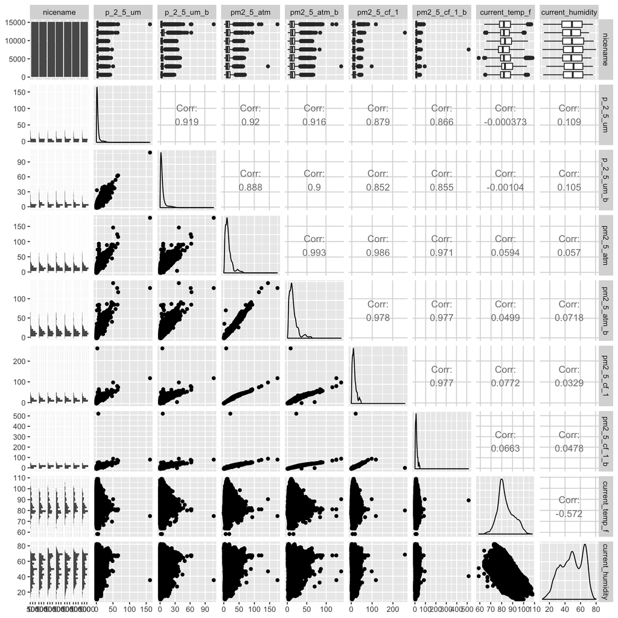

```r
air_quality %>%
  clean_names() %>%
  select(
    timestamp_iso,
    nicename,
    p_2_5_um,
    p_2_5_um_b,
    pm2_5_atm,
    pm2_5_atm_b,
    pm2_5_cf_1,
    pm2_5_cf_1_b,
    current_temp_f,
    current_humidity
  ) ->
  aq_limited

ggpairs(aq_limited %>% select(-timestamp_iso) )
```

### Air Quality Detailed Plots

Let’s look at a few of these individually.

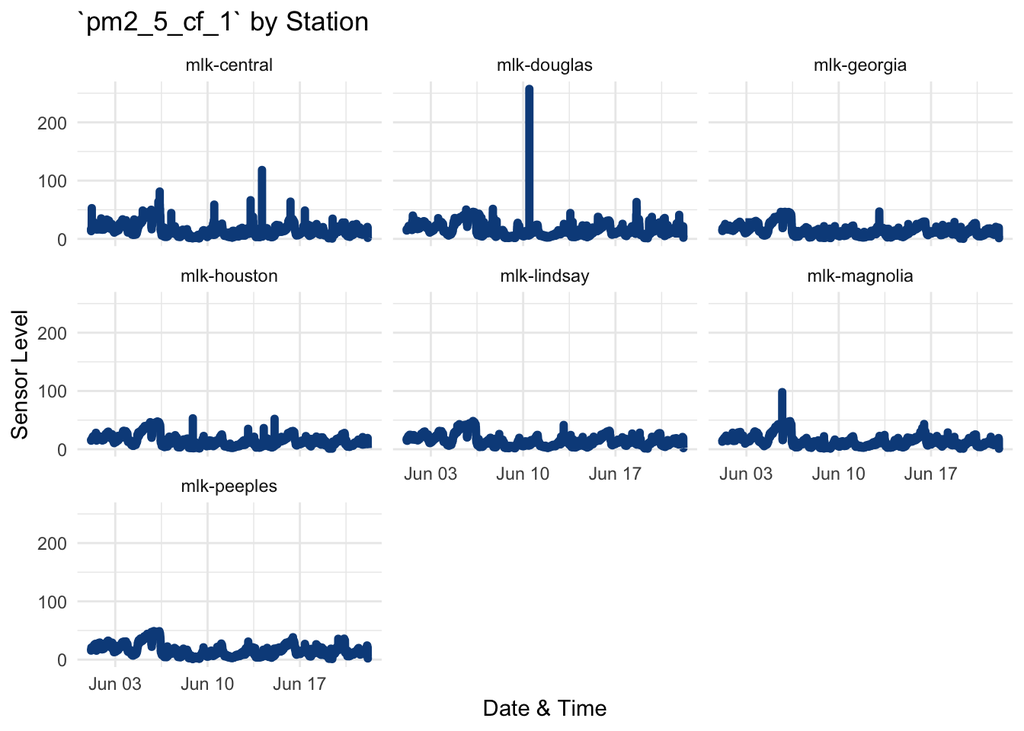

```r
ggplot(aq_limited) +
 aes(x = timestamp_iso, y = pm2_5_cf_1) +
 geom_line(size = 1.92, colour = "#0c4c8a") +
 labs(x = "Date & Time", y = "Sensor Level", title = "`pm2_5_cf_1` by Station") +
 theme_minimal() +
 facet_wrap(vars(nicename))
```

I don’t know what it means exactly, but I bet there’s hella traffic at douglas compared to the other stations. The volatility there is off the hook (comparatively)

Let’s look at the same data layered on the same graph. I can’t tell if they move together… seems like they should to some degree:

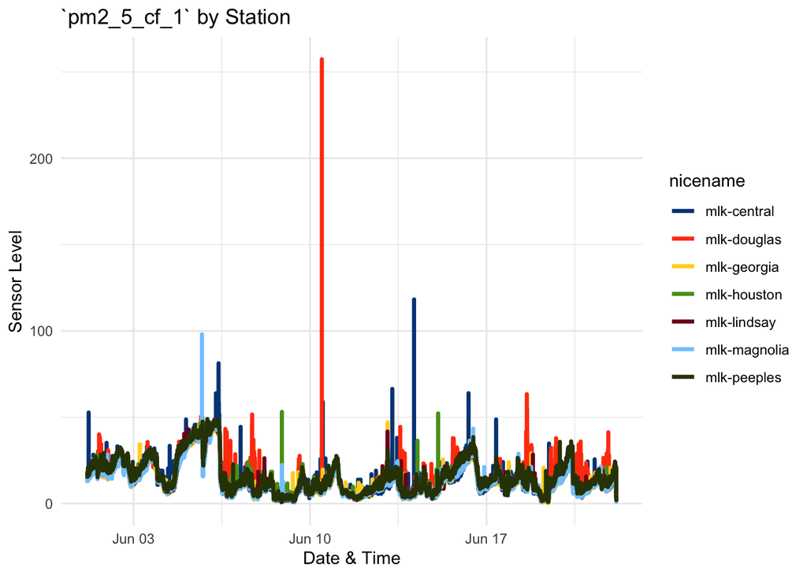

```r
ggplot(aq_limited) +
 aes(x = timestamp_iso, y = pm2_5_cf_1, color = nicename) +
 geom_line(size = 1.2) +
 labs(x = "Date & Time", y = "Sensor Level", title = "`pm2_5_cf_1` by Station") +
 theme_minimal() +
 scale_colour_calc()
```

Well that’s sort of noisy. I wonder what the correlation is. Let’s reshape the data to look at correlations quickly.

Do a quick reshape of the data to get the stations in columns…

I discovered in the data some time and location combinations that have multiple readings. I would not expect this. But since it’s there, we’ll just average them. And the data is irregular. So we need to put this junk in buckets. I’m thinking maybe 10 min buckets? Let’s see if we can do that. Feels like a job for grouping by a floor value. We can get the 10 minute interval floors from the `lubridate` package.

```r
aq_limited %>%
  select(timestamp_iso, nicename, pm2_5_cf_1) %>%
  group_by(timestamp_iso, nicename) %>%
  summarize(pm2_5_cf_1 = mean(pm2_5_cf_1))  %>%
  group_by(timemark = floor_date(timestamp_iso, "10 mins"), nicename) %>%
  select(-timestamp_iso) %>%
  summarize_all(mean, na.rm = TRUE) %>%
  arrange(timemark) ->
  aq_limited_long

aq_limited_long %>%
  spread(nicename, pm2_5_cf_1) ->
  aq_limited_wide

kable(head(aq_limited_wide, 20))
```

| timemark | mlk-central | mlk-douglas | mlk-georgia | mlk-houston | mlk-lindsay | mlk-magnolia | mlk-peeples |
| --- | --- | --- | --- | --- | --- | --- | --- |
| 2019-06-01 04:00:00 | 14.074 | 14.810 | 14.252 | 15.104 | 16.370 | 13.198 | 16.104 |
| 2019-06-01 04:10:00 | 13.724 | 15.110 | 14.556 | 15.348 | 15.796 | 13.840 | 16.790 |
| 2019-06-01 04:20:00 | 16.012 | 15.262 | 14.818 | 15.348 | 15.882 | 14.568 | 18.332 |
| 2019-06-01 04:30:00 | 15.868 | 15.578 | 15.718 | 15.496 | 16.082 | 15.310 | 18.888 |
| 2019-06-01 04:40:00 | 16.512 | 16.026 | 14.790 | 16.282 | 15.912 | 14.280 | 17.936 |
| 2019-06-01 04:50:00 | 17.706 | 16.394 | 15.582 | 16.014 | 16.026 | 14.802 | 17.778 |
| 2019-06-01 05:00:00 | 16.854 | 16.340 | 15.510 | 16.010 | 16.014 | 14.686 | 18.460 |
| 2019-06-01 05:10:00 | 36.456 | 16.600 | 14.906 | 16.864 | 15.640 | 14.808 | 17.342 |
| 2019-06-01 05:20:00 | 16.050 | 16.954 | 15.640 | 16.988 | 16.924 | 14.804 | 17.684 |
| 2019-06-01 05:30:00 | 16.546 | 16.924 | 16.992 | 16.482 | 16.922 | 14.898 | 17.538 |
| 2019-06-01 05:40:00 | 15.988 | 16.918 | 16.716 | 17.112 | 17.318 | 15.062 | 17.538 |
| 2019-06-01 05:50:00 | 16.162 | 17.554 | 17.244 | 17.292 | 17.104 | 16.340 | 18.030 |
| 2019-06-01 06:00:00 | 16.534 | 17.048 | 16.186 | 17.166 | 16.830 | 15.722 | 18.078 |
| 2019-06-01 06:10:00 | 16.604 | 17.836 | 16.828 | 18.946 | 18.668 | 17.094 | 18.842 |
| 2019-06-01 06:20:00 | 17.944 | 17.924 | 16.218 | 18.114 | 17.426 | 16.522 | 18.946 |
| 2019-06-01 06:30:00 | 17.330 | 17.580 | 16.736 | 17.330 | 17.268 | 16.812 | 18.914 |
| 2019-06-01 06:40:00 | 18.152 | 17.498 | 17.354 | 17.716 | 17.496 | 17.272 | 19.134 |
| 2019-06-01 06:50:00 | 18.974 | 17.890 | 18.476 | 17.786 | 17.336 | 16.236 | 20.290 |
| 2019-06-01 07:00:00 | 19.712 | 18.052 | 18.446 | 18.516 | 17.868 | 16.192 | 19.876 |
| 2019-06-01 07:10:00 | 18.054 | 18.812 | 17.228 | 18.630 | 18.368 | 17.426 | 20.712 |

That looks better. Let’s see what’s going on here…

Let’s plot and look at the pairs plot with correlations:

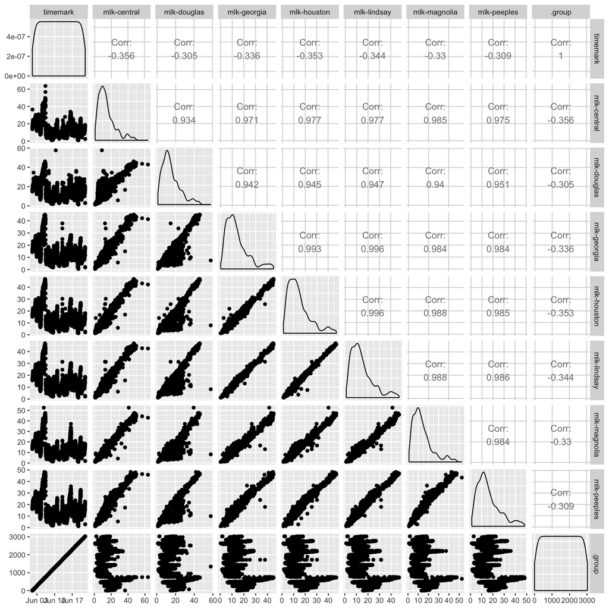

```r
aq_limited_wide %>%
  select(-timemark) %>%
  ggpairs()
```

As I would suspect, these are all pretty correlated. But that Douglas intersection though… it’s different. I suspect high traffic (again). Still correlated but it doesn’t drop as low as quickly as the others… I wonder if there’s something dusty near there or if it just gets more traffic?

Since we’re slicing and dicing, let’s look at `temp` vs. `p_2_5_um` for each station:

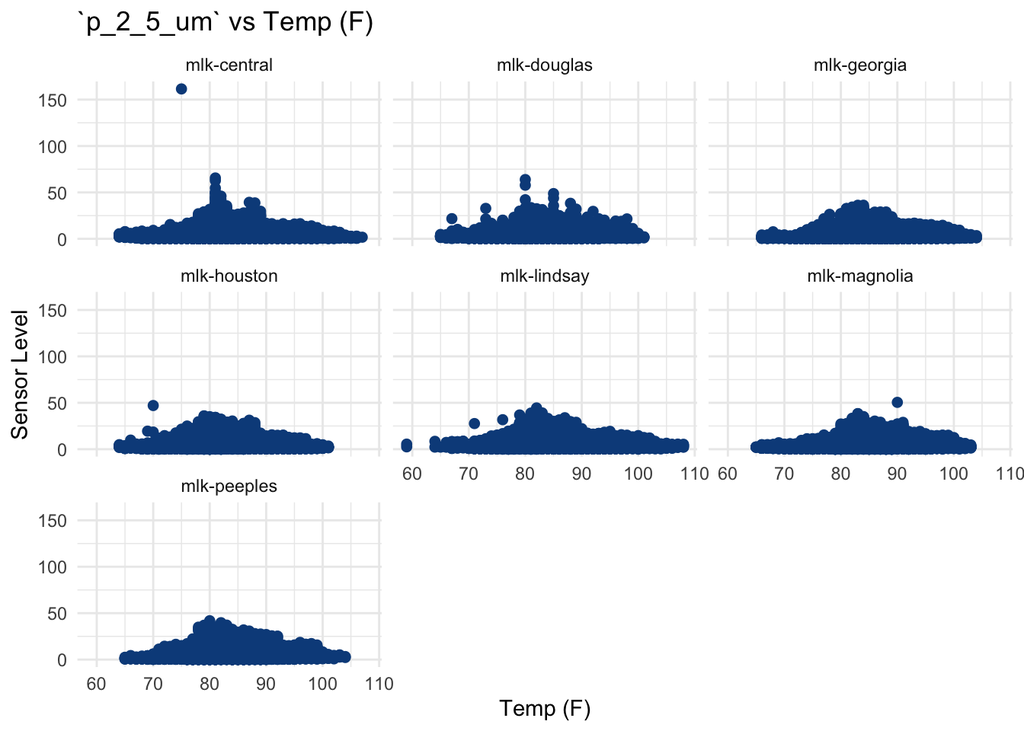

```r
ggplot(aq_limited) +
 aes(x = current_temp_f, y = p_2_5_um) +
 geom_point(size = 1.92, colour = "#0c4c8a") +
 labs(x = "Temp (F)", y = "Sensor Level", title = "`p_2_5_um` vs Temp (F)") +
 theme_minimal() +
 facet_wrap(vars(nicename))
```

That’s not as insightful as I had hoped. Let’s look at humidity:

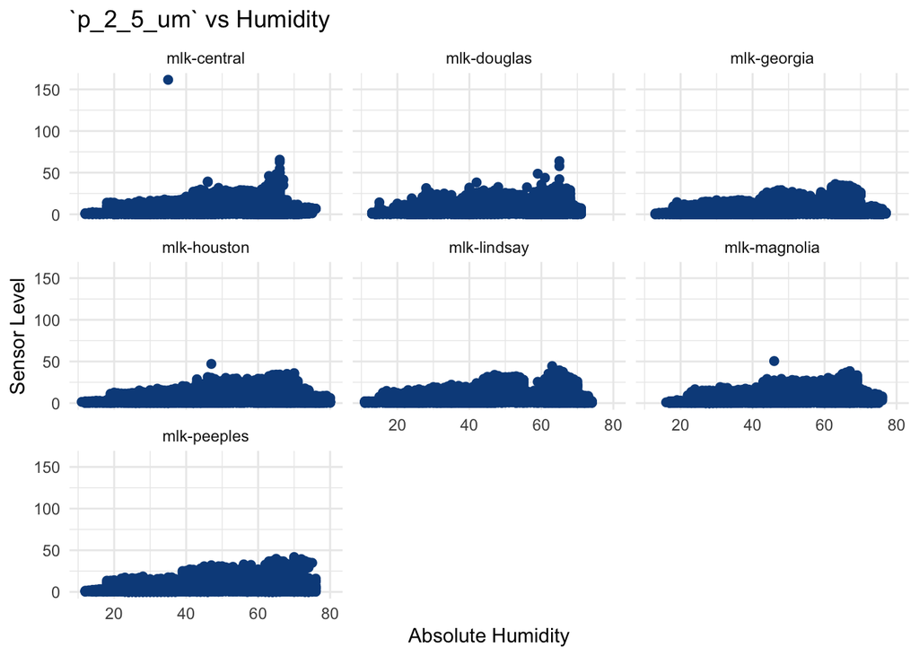

```r
ggplot(aq_limited) +
 aes(x = current_humidity, y = p_2_5_um) +
 geom_point(size = 1.92, colour = "#0c4c8a") +
 labs(x = "Absolute Humidity", y = "Sensor Level", title = "`p_2_5_um` vs Humidity") +
 theme_minimal() +
 facet_wrap(vars(nicename))
```

### Air Quality Station Map

When I first got these data, I don’t know where it was collected, but I suspect it was around Chattanooga. Let’s plot the locations and see:

```r
library(ggmap)
library(sf)
library(mapview)
library(leaflet)
```

```r
# grab the coordinates
air_quality %>%
  group_by(nicename, lat, lon) %>%
  summarize(obs_count = n()) ->
  obs_location

# turn them into a spatial sf object for mapping
obs_location_sf <-
  st_as_sf(obs_location,
           coords = c("lon", "lat"),
           crs = 4326)

# build the map
m1 <- mapview(obs_location_sf, legend = FALSE)

# add the names as labels
l1  <- addStaticLabels(
  m1,
  label = obs_location_sf$nicename,
  textsize = "20px",
  direction = 'left'
)

l1
```

[interactive chart not shown]

Cool, they are all right up one strip in Chattanooga. I guess now we know what the MLK prefix in all the station names stands for. Looks like the stations are named after MLK and the cross street. Makes sense.

## Video Events

We should do something similar to the above with the video data.

We’ll start with a `skim`:

### Video Skim

```r
video_events <- read_csv("01_data/CSCDC+Dataset/video_event_csv/all.csv")
skim(video_events)  %>% kable()
```

Skim summary statistics  
n obs: 4070343  
n variables: 11

Variable type: character

| variable | missing | complete | n | min | max | empty | n_unique |
| --- | --- | --- | --- | --- | --- | --- | --- |
| camera_id | 0 | 4070343 | 4070343 | 17 | 18 | 0 | 10 |
| id | 0 | 4070343 | 4070343 | 36 | 36 | 0 | 4070342 |
| label | 0 | 4070343 | 4070343 | 3 | 13 | 0 | 18 |
| locations | 0 | 4070343 | 4070343 | 190 | 9897 | 0 | 4070342 |
| pole_id | 0 | 4070343 | 4070343 | 13 | 14 | 0 | 10 |

Variable type: logical

| variable | missing | complete | n | mean | count |
| --- | --- | --- | --- | --- | --- |
| intersection | 0 | 4070343 | 4070343 | 0.84 | TRU: 3405701, FAL: 664642, NA: 0 |

Variable type: numeric

| variable | missing | complete | n | mean | sd | p0 | p25 | p50 | p75 | p100 | hist |
| --- | --- | --- | --- | --- | --- | --- | --- | --- | --- | --- | --- |
| hit_counts | 0 | 4070343 | 4070343 | 5.35 | 4.78 | 2 | 2 | 3 | 7 | 82 | ▇▁▁▁▁▁▁▁ |
| timestamp | 0 | 4070343 | 4070343 | 1.6e+12 | 5.3e+08 | 1.6e+12 | 1.6e+12 | 1.6e+12 | 1.6e+12 | 1.6e+12 | ▅▇▇▆▇▆▆▇ |
| Unnamed: 0 | 0 | 4070343 | 4070343 | 2e+06 | 1175006.96 | 0 | 1e+06 | 2e+06 | 3052756.5 | 4070342 | ▇▇▇▇▇▇▇▇ |
| X1 | 0 | 4070343 | 4070343 | 2e+06 | 1175006.96 | 0 | 1e+06 | 2e+06 | 3052756.5 | 4070342 | ▇▇▇▇▇▇▇▇ |

Variable type: POSIXct

| variable | missing | complete | n | min | max | median | n_unique |
| --- | --- | --- | --- | --- | --- | --- | --- |
| timestamp-iso | 0 | 4070343 | 4070343 | 2019-06-01 | 2019-06-22 | 2019-06-11 | 3876225 |

```r
head(video_events)
```

```
## # A tibble: 6 x 11
##      X1 `Unnamed: 0` camera_id hit_counts id    intersection label
##   <dbl>        <dbl> <chr>          <dbl> <chr> <lgl>        <chr>
## 1     0            0 mlk-cent…          7 fb33… TRUE         car
## 2     1            1 mlk-cent…          2 12a6… TRUE         car
## 3     2            2 mlk-cent…          2 8430… TRUE         car
## 4     3            3 mlk-cent…         14 d5c5… TRUE         car
## 5     4            4 mlk-cent…          8 8328… TRUE         car
## 6     5            5 mlk-cent…          6 7bc4… TRUE         car
## # … with 4 more variables: locations <chr>, pole_id <chr>,
## #   timestamp <dbl>, `timestamp-iso` <dttm>
```

So there’s a lot going on in there… let’s strip out some unique values for a few of the fields so we can see what we’re dealing with.

So there’s an `id` field that has a CUSIP for each vehicle… let’s check that out

```r
video_events %>%
  select(id) %>%
  distinct(id) %>%
  summarize(n())
```

```
## # A tibble: 1 x 1
##     `n()`
##     <int>
## 1 4070342
```

So there are a little over 4m unique vehicle ids. Interesting.

I wonder if any ids are in there multiple times.

```r
video_events %>%
  group_by(id) %>%
  summarize(rec_count = n()) %>%
  filter(rec_count > 1) ->
  has_dupe

has_dupe
```

```
## # A tibble: 1 x 2
##   id                                   rec_count
##   <chr>                                    <int>
## 1 b3cb7029-86ed-47e0-a634-7ae1ba9d3076         2
```

One… weird. I wonder if that’s a random CUSIP clash (unlikely).

```r
video_events %>%
  inner_join(has_dupe) ->
  double_up
double_up
```

```
## # A tibble: 2 x 12
##       X1 `Unnamed: 0` camera_id hit_counts id    intersection label
##    <dbl>        <dbl> <chr>          <dbl> <chr> <lgl>        <chr>
## 1 4.03e6      4029658 mlk-cent…          8 b3cb… TRUE         car
## 2 4.03e6      4032606 mlk-cent…          8 b3cb… TRUE         car
## # … with 5 more variables: locations <chr>, pole_id <chr>,
## #   timestamp <dbl>, `timestamp-iso` <dttm>, rec_count <int>
```

That’s just straight up a dupe record. Well it probably won’t cause us any trouble.. but we’ll kick out one manually for OCD reasons.

```r
double_up %>%
  summarize(max(X1)) %>%
  pluck(1) ->
  bad_point

video_events %>%
  filter(X1 != bad_point) ->
  video_events_nodupes
```

Let’s look at the cameras and see what’s going on…

```r
video_events_nodupes %>%
  select(camera_id) %>%
  arrange(camera_id) %>%
  distinct
```

```
## # A tibble: 10 x 1
##    camera_id
##    <chr>
##  1 mlk-central-cam-2
##  2 mlk-douglas-cam-1
##  3 mlk-douglas-cam-2
##  4 mlk-georgia-cam-1
##  5 mlk-georgia-cam-3
##  6 mlk-houston-cam-1
##  7 mlk-lindsay-cam-2
##  8 mlk-magnolia-cam-2
##  9 mlk-peeples-cam-1
## 10 mlk-peeples-cam-3
```

Oh… some intersections have two cameras.. but some only have one. Interesting.

I think for now we just want data from one camera per intersection… so let’s pick the camera with the most traffic and also adjust the names so we can use them later to match to pm data

```r
video_events_nodupes %>%
  group_by(camera_id) %>%
  summarize(rec_count = n()) %>%
  separate(camera_id, into  = c("street1", "street2", "street3", "street4"), sep="-", remove = FALSE)  %>%
  mutate(nicename = paste(street1, street2, sep = "-")) %>%
  select(nicename, camera_id, rec_count)  %>%
  group_by(nicename) %>%
  top_n(1, rec_count) %>%
  ungroup %>%
  {.} ->
  cameras

cameras
```

```
## # A tibble: 7 x 3
##   nicename     camera_id          rec_count
##   <chr>        <chr>                  <int>
## 1 mlk-central  mlk-central-cam-2     880557
## 2 mlk-douglas  mlk-douglas-cam-1     287188
## 3 mlk-georgia  mlk-georgia-cam-3     623252
## 4 mlk-houston  mlk-houston-cam-1     568195
## 5 mlk-lindsay  mlk-lindsay-cam-2     490929
## 6 mlk-magnolia mlk-magnolia-cam-2    188323
## 7 mlk-peeples  mlk-peeples-cam-3     448677
```

Join that back to the video data to get just one cam per intersetion

```r
video_events_nodupes %>%
  inner_join(cameras %>% select(camera_id, nicename)) ->
  video_events_nodupes_1per
```

in our initial `skim` we saw we have a field called `label` that has 18 unique values… let’s look at that

```r
video_events_nodupes_1per %>%
  group_by(label) %>%
  summarize(row_count = n()) %>%
  arrange(row_count)
```

```
## # A tibble: 17 x 2
##    label         row_count
##    <chr>             <int>
##  1 stop sign             3
##  2 parking meter        23
##  3 suitcase             28
##  4 aeroplane            33
##  5 dog                  44
##  6 handbag              57
##  7 bird                 79
##  8 boat                 81
##  9 backpack            178
## 10 umbrella            255
## 11 fire hydrant        951
## 12 bicycle            3690
## 13 motorbike          6509
## 14 bus               17207
## 15 truck            105490
## 16 person           126431
## 17 car             3226062
```

Oh… that’s a lot of stuff.

```r
video_events_nodupes_1per %>%
  filter(label %in% c("car","bus","truck", "motorbike")) %>%
  clean_names() %>%
  {.} ->
  video_events_nodupes_1per_filtered
```

so let’s group these data into 10 minute buckets the way we did with the pm data:

```r
video_events_nodupes_1per_filtered %>%
  group_by(timemark = floor_date(timestamp_iso, "10 mins"), nicename, label) %>%
  summarize(vehicle_count = n())  ->
  video_events_summarized_long

head(video_events_summarized_long)
```

```
## # A tibble: 6 x 4
## # Groups:   timemark, nicename [4]
##   timemark            nicename    label vehicle_count
##   <dttm>              <chr>       <chr>         <int>
## 1 2019-06-01 04:00:00 mlk-central car             154
## 2 2019-06-01 04:00:00 mlk-central truck             3
## 3 2019-06-01 04:00:00 mlk-douglas car              29
## 4 2019-06-01 04:00:00 mlk-georgia car             169
## 5 2019-06-01 04:00:00 mlk-georgia truck             5
## 6 2019-06-01 04:00:00 mlk-houston bus               1
```

That’s cool, but let’s make it wide instead of long:

```r
video_events_summarized_long %>%
  group_by(nicename, label) %>%

  spread(label, vehicle_count) %>%
  replace(is.na(.), 0) ->
  video_events_summarized_wide

head(video_events_summarized_wide)
```

```
## # A tibble: 6 x 6
## # Groups:   nicename [6]
##   timemark            nicename       bus   car motorbike truck
##   <dttm>              <chr>        <dbl> <dbl>     <dbl> <dbl>
## 1 2019-06-01 04:00:00 mlk-central      0   154         0     3
## 2 2019-06-01 04:00:00 mlk-douglas      0    29         0     0
## 3 2019-06-01 04:00:00 mlk-georgia      0   169         0     5
## 4 2019-06-01 04:00:00 mlk-houston      1   151         1     1
## 5 2019-06-01 04:00:00 mlk-lindsay      0   145         0     1
## 6 2019-06-01 04:00:00 mlk-magnolia     0    22         0     0
```

Let’s join the ‘wide’ video data to the polution data.

```r
aq_limited_long %>%
  inner_join(video_events_summarized_wide) %>%
  rowwise() %>%
  mutate(total_traffic = sum(bus, car, motorbike, truck) ) ->
  pm_traffic
```

Do a quick time plot of each intersection (again)

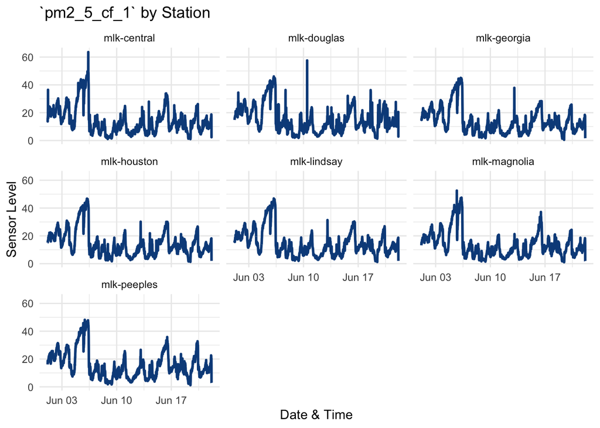

```r
ggplot(pm_traffic) +
 aes(x = timemark, y = pm2_5_cf_1) +
 geom_line(size = 1, colour = "#0c4c8a") +
 labs(x = "Date & Time", y = "Sensor Level", title = "`pm2_5_cf_1` by Station") +
 theme_minimal() +
 facet_wrap(vars(nicename))
```

And traffic:

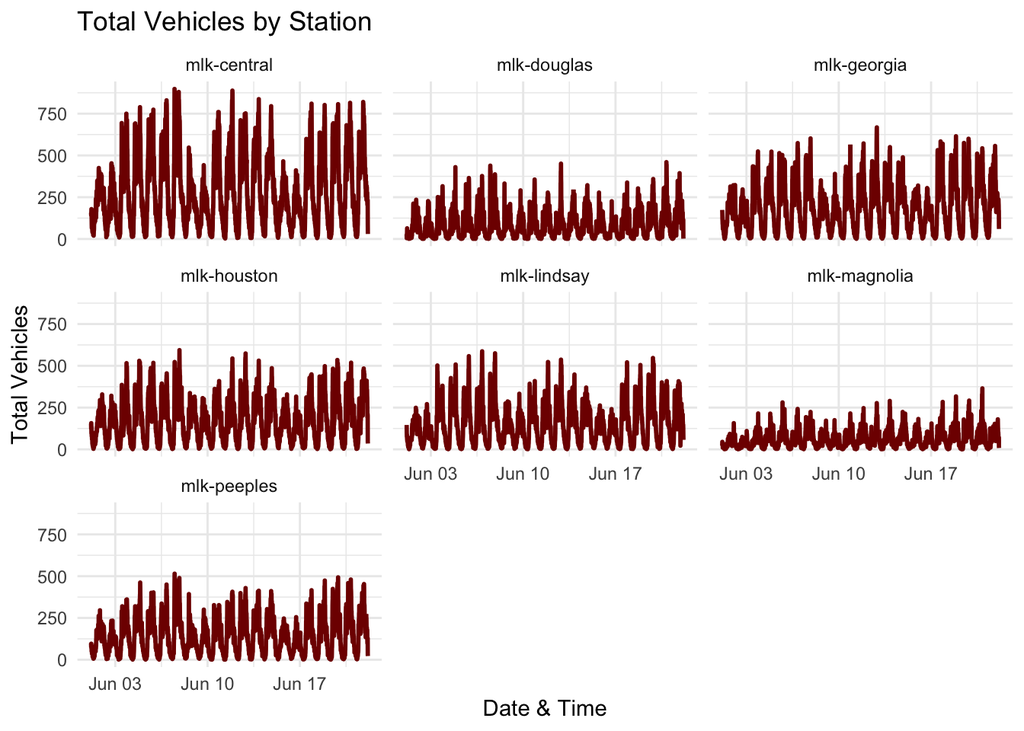

```r
ggplot(pm_traffic) +
 aes(x = timemark, y = total_traffic) +
 geom_line(size = 1, colour = "#800000") +
 labs(x = "Date & Time", y = "Total Vehicles", title = "Total Vehicles by Station") +
 theme_minimal() +
 facet_wrap(vars(nicename))
```

Well that’s some regular looking cycles…

Let’s build a super simple linear model:

```r
library(parsnip)
library(broom)
```

```r
lm(data = pm_traffic, pm2_5_cf_1 ~ bus + car + motorbike + truck) ->
  linear_model

summary(linear_model)
```

```
##
## Call:
## lm(formula = pm2_5_cf_1 ~ bus + car + motorbike + truck, data = pm_traffic)
##
## Residuals:
##     Min      1Q  Median      3Q     Max
## -14.223  -6.621  -2.291   4.122  48.312
##
## Coefficients:
##               Estimate Std. Error t value Pr(>|t|)
## (Intercept) 15.5887601  0.0993488 156.909  < 2e-16 ***
## bus         -0.0301903  0.0555936  -0.543 0.587098
## car         -0.0067491  0.0007974  -8.464  < 2e-16 ***
## motorbike   -0.1945797  0.0527587  -3.688 0.000226 ***
## truck       -0.0022071  0.0147943  -0.149 0.881410
## ---
## Signif. codes:  0 '***' 0.001 '**' 0.01 '*' 0.05 '.' 0.1 ' ' 1
##
## Residual standard error: 9.412 on 21095 degrees of freedom
## Multiple R-squared:  0.01232,    Adjusted R-squared:  0.01213
## F-statistic: 65.79 on 4 and 21095 DF,  p-value: < 2.2e-16
```

So right out of the gate we have issues…. the sign on the coefficients is not at all as expected. We would expect more traffic = more particulates… but this models says the opposite. That’s a huge warning sign.

Let’s plot the actual vs. modeled

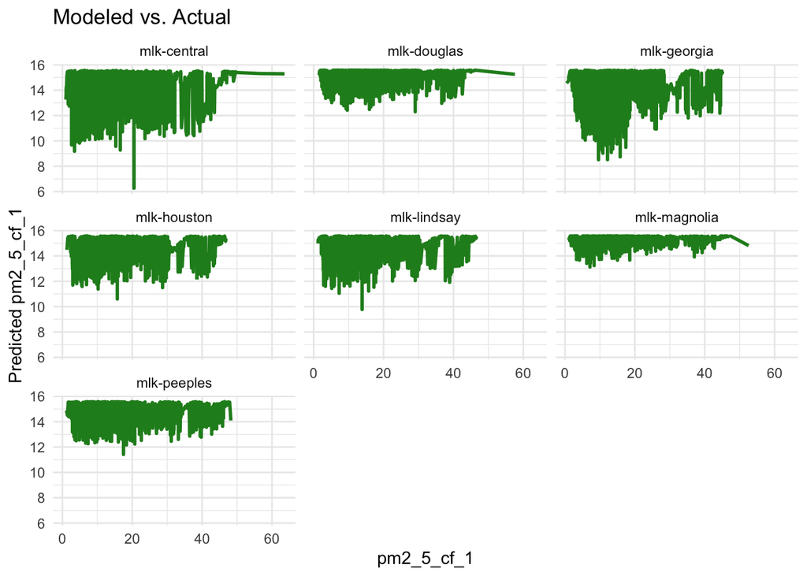

```r
pm_traffic %>%
  bind_cols( tibble(.pred = predict(linear_model, new_data = pm_traffic)) ) ->
  predicted_lm

ggplot(predicted_lm) +
 aes(x = pm2_5_cf_1, y = .pred) +
 geom_line(size = 1, colour = "#228B22") +
 labs(x = "pm2_5_cf_1", y = "Predicted pm2_5_cf_1", title = "Modeled vs. Actual") +
 theme_minimal() +
 facet_wrap(vars(nicename))
```

Well that’s amazingly shitty.

Let’s look at a quick correlation matrix:

```r
pm_traffic %>%
  select(pm2_5_cf_1, bus, car,  motorbike, truck, total_traffic) %>%
  cor()
```

[output not shown]

Weird… mos def negative correlations

Maybe if we break it into intersections and just look at total traffic correlation to pm

```r
pm_traffic %>%
  group_by(nicename) %>%
  summarize(correl = cor(pm2_5_cf_1, total_traffic))
```

[output not shown]

Total traffic is always just a little bit neg correlated….

So clearly something else is driving the particulate matter.

Let’s bring in some weather data. I ran this previously and it takes a few minutes so I saved the results to a csv:

```r
library(rWind)
# chattanooga is 35.0456° N, 85.3097° W

dt <- seq(ymd_hms(paste(2019, 6, 01, 00, 00, 00, sep = "-")),
          ymd_hms(paste(2019, 7, 01, 00, 00, 00, sep = "-")), by = "3 hours")
ww <- wind.dl_2(dt, -85.3097,-85.3097, 35.0456, 35.0456)

tidy (ww) %>%
  write_csv("01_data/wind_data.csv")
```

Read in that csv

```r
wind_data <- read_csv("01_data/wind_data.csv")
```

so we have a known date issue… not 100% sure what time zone the traffic data is… assuming UTC, but I bet it’s eastern. Have to fix this later

now we need to join every intersection to the wind data.